# External Lab

Here each question is of 1 mark.

# Multiple Linear Regression

## Problem Statement

Use Multiple Linear Regression to **predict the consumption of petrol** given relevant variables are the petrol tax, the per capita, income, the number of miles of paved highway, and the proportion of the population with driver's licenses.

## Dataset

There are 48 rows of data. The data include:

```
  I,  the index;
  A1, the petrol tax;
  A2, the per capita income;
  A3, the number of miles of paved highway;
  A4, the proportion of drivers;
  B,  the consumption of petrol.
```

### Reference

```
Helmut Spaeth,
Mathematical Algorithms for Linear Regression,
Academic Press, 1991,
ISBN 0-12-656460-4.

S Weisberg,
Applied Linear Regression,
New York, 1980, pages 32-33.
```

## Question 1 - Exploratory Data Analysis

*Read the dataset given in file named **'petrol.csv'**. Check the statistical details of the dataset.*

**Hint:** You can use **df.describe()**

```python
import pandas as pd
petrol=pd.read_csv("petrol.csv")
petrol.describe()
petrol.head(50)
```

|  | tax | income | highway | dl | consumption |
| --- | --- | --- | --- | --- | --- |
| 0 | 9.00 | 3571 | 1976 | 0.525 | 541 |
| 1 | 9.00 | 4092 | 1250 | 0.572 | 524 |
| 2 | 9.00 | 3865 | 1586 | 0.580 | 561 |
| 3 | 7.50 | 4870 | 2351 | 0.529 | 414 |
| 4 | 8.00 | 4399 | 431 | 0.544 | 410 |
| 5 | 10.00 | 5342 | 1333 | 0.571 | 457 |
| 6 | 8.00 | 5319 | 11868 | 0.451 | 344 |
| 7 | 8.00 | 5126 | 2138 | 0.553 | 467 |
| 8 | 8.00 | 4447 | 8577 | 0.529 | 464 |
| 9 | 7.00 | 4512 | 8507 | 0.552 | 498 |
| 10 | 8.00 | 4391 | 5939 | 0.530 | 580 |
| 11 | 7.50 | 5126 | 14186 | 0.525 | 471 |
| 12 | 7.00 | 4817 | 6930 | 0.574 | 525 |
| 13 | 7.00 | 4207 | 6580 | 0.545 | 508 |
| 14 | 7.00 | 4332 | 8159 | 0.608 | 566 |
| 15 | 7.00 | 4318 | 10340 | 0.586 | 635 |
| 16 | 7.00 | 4206 | 8508 | 0.572 | 603 |
| 17 | 7.00 | 3718 | 4725 | 0.540 | 714 |
| 18 | 7.00 | 4716 | 5915 | 0.724 | 865 |
| 19 | 8.50 | 4341 | 6010 | 0.677 | 640 |
| 20 | 7.00 | 4593 | 7834 | 0.663 | 649 |
| 21 | 8.00 | 4983 | 602 | 0.602 | 540 |
| 22 | 9.00 | 4897 | 2449 | 0.511 | 464 |
| 23 | 9.00 | 4258 | 4686 | 0.517 | 547 |
| 24 | 8.50 | 4574 | 2619 | 0.551 | 460 |
| 25 | 9.00 | 3721 | 4746 | 0.544 | 566 |
| 26 | 8.00 | 3448 | 5399 | 0.548 | 577 |
| 27 | 7.50 | 3846 | 9061 | 0.579 | 631 |
| 28 | 8.00 | 4188 | 5975 | 0.563 | 574 |
| 29 | 9.00 | 3601 | 4650 | 0.493 | 534 |
| 30 | 7.00 | 3640 | 6905 | 0.518 | 571 |
| 31 | 7.00 | 3333 | 6594 | 0.513 | 554 |
| 32 | 8.00 | 3063 | 6524 | 0.578 | 577 |
| 33 | 7.50 | 3357 | 4121 | 0.547 | 628 |
| 34 | 8.00 | 3528 | 3495 | 0.487 | 487 |
| 35 | 6.58 | 3802 | 7834 | 0.629 | 644 |
| 36 | 5.00 | 4045 | 17782 | 0.566 | 640 |
| 37 | 7.00 | 3897 | 6385 | 0.586 | 704 |
| 38 | 8.50 | 3635 | 3274 | 0.663 | 648 |
| 39 | 7.00 | 4345 | 3905 | 0.672 | 968 |
| 40 | 7.00 | 4449 | 4639 | 0.626 | 587 |
| 41 | 7.00 | 3656 | 3985 | 0.563 | 699 |
| 42 | 7.00 | 4300 | 3635 | 0.603 | 632 |
| 43 | 7.00 | 3745 | 2611 | 0.508 | 591 |
| 44 | 6.00 | 5215 | 2302 | 0.672 | 782 |
| 45 | 9.00 | 4476 | 3942 | 0.571 | 510 |
| 46 | 7.00 | 4296 | 4083 | 0.623 | 610 |
| 47 | 7.00 | 5002 | 9794 | 0.593 | 524 |

# Question 2 - Cap outliers

Find the outliers and cap them. (Use (Q1 - 1.5 *IQR) as the minimum cap and (Q3 + 1.5* IQR) as the max cap. The decision criteria is you should consider the datapoints which only falls within this range. The data points which fall outside this range are outliers and the entire row needs to be removed

```python
Q1 = petrol.quantile(0.25)
Q3 = petrol.quantile(0.75)
IQR = Q3 - Q1
print(IQR)
print((petrol < (Q1 - 1.5 * IQR)) |(petrol> (Q3 + 1.5 * IQR)))
petrol_out = petrol[~((petrol < (Q1 - 1.5 * IQR)) |(petrol > (Q3 + 1.5 * IQR))).any(axis=1)]
petrol_out.shape
```

```
tax                1.1250
 income          839.7500
 highway        4045.7500
 dl                0.0655
 consumption     123.2500
dtype: float64
      tax   income   highway     dl   consumption
0   False    False     False  False         False
1   False    False     False  False         False
2   False    False     False  False         False
3   False    False     False  False         False
4   False    False     False  False         False
5    True    False     False  False         False
6   False    False     False  False         False
7   False    False     False  False         False
```

[output cut: 40 more lines]

```
(43, 5)
```

# Question 3 - Independent variables and collinearity

Which attributes seems to have stronger association with the dependent variable consumption?

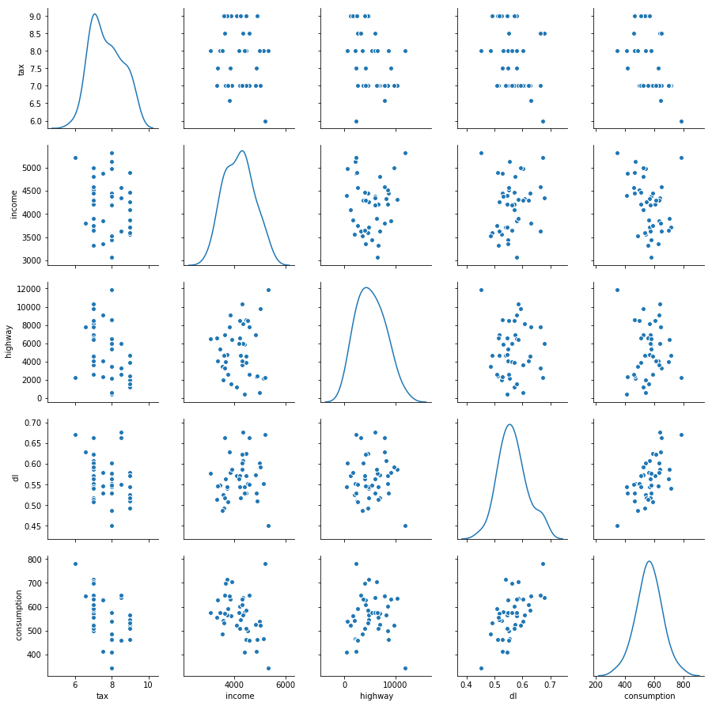

```python
import numpy as np
import seaborn as sbn
import matplotlib as plt
np.corrcoef(petrol_out)
#sbn.heatmap(np.corrcoef(petrol_out))
sbn.pairplot(petrol_out, diag_kind='kde')
```

Insights : As tax increases the consumption decreases. As number of drivers is more consumption is more

# Question 4 - Transform the dataset

Divide the data into feature(X) and target(Y) sets.

```python
print(petrol_out.shape)
petrol_out.shape
petrol_out.info()
y=petrol_out[[' consumption']]
x=petrol_out[['tax',' dl']]
```

```
(43, 5)
<class 'pandas.core.frame.DataFrame'>
Int64Index: 43 entries, 0 to 47
Data columns (total 5 columns):
tax             43 non-null float64
 income         43 non-null int64
 highway        43 non-null int64
 dl             43 non-null float64
 consumption    43 non-null int64
dtypes: float64(2), int64(3)
memory usage: 2.0 KB
```

```python
petrol_out.corr()
```

|  | tax | income | highway | dl | consumption |
| --- | --- | --- | --- | --- | --- |
| tax | 1.000000 | -0.109537 | -0.390602 | -0.314702 | -0.446116 |
| income | -0.109537 | 1.000000 | 0.051169 | 0.150689 | -0.347326 |
| highway | -0.390602 | 0.051169 | 1.000000 | -0.016193 | 0.034309 |
| dl | -0.314702 | 0.150689 | -0.016193 | 1.000000 | 0.611788 |
| consumption | -0.446116 | -0.347326 | 0.034309 | 0.611788 | 1.000000 |

# Question 5 - Split data into train, test sets

Divide the data into training and test sets with 80-20 split using scikit-learn. Print the shapes of training and test feature sets.

```python
from sklearn.model_selection import train_test_split
X_train, X_test, y_train, y_test = train_test_split(x, y, test_size=0.20 , random_state=1)
print(X_train.shape)
print(y_train.shape)
print(X_test.shape)
print(y_test.shape)
```

```
(34, 2)
(34, 1)
(9, 2)
(9, 1)
```

# Question 6 - Build Model

Estimate the coefficients for each input feature. Construct and display a dataframe with coefficients and X.columns as columns

```python
from sklearn.linear_model import LinearRegression
regression_model = LinearRegression()
regression_model.fit(X_train, y_train)
print(regression_model.coef_)
print(regression_model.intercept_)
```

```
[[-30.70924255 892.88620875]]
[292.55096525]
```

# Question 7 - Evaluate the model

Calculate the accuracy score for the above model.

```python
import matplotlib.pyplot as plot
predictions = regression_model.predict(X_test);
#plot.scatter(y_test,predictions)
from sklearn.metrics import mean_squared_error
from sklearn.metrics import r2_score
RMSE = mean_squared_error(y_test,predictions)
import math
print(math.sqrt(RMSE))
r2= r2_score(y_test,predictions)
print(r2)
```

```
69.02352698398606
0.2876056314158515
```

# Question 8: Repeat the same Multi linear regression modelling by adding both Income and Highway features

Find R2

```python
x=petrol_out[['tax',' dl',' income',' highway']]
from sklearn.model_selection import train_test_split
X_train, X_test, y_train, y_test = train_test_split(x, y, test_size=0.20 , random_state=1)

from sklearn.linear_model import LinearRegression
regression_model = LinearRegression()
regression_model.fit(X_train, y_train)
print(regression_model.coef_)
print(regression_model.intercept_)


from sklearn.metrics import mean_squared_error
from sklearn.metrics import r2_score
RMSE = mean_squared_error(y_test,predictions)
import math
print(math.sqrt(RMSE))
r2= r2_score(y_test,predictions)
print(r2)
```

```
[[-3.94115836e+01  9.50882744e+02 -6.26281401e-02 -3.02198704e-03]]
[607.71890891]
69.02352698398606
0.2876056314158515
```

# Question 9: Print the coefficients of the multilinear regression model

```python
data_train = pd.concat([X_train, y_train], axis=1)
data_train.head()
data_train.columns = data_train.columns.str.strip()
#data_train.rename(columns=lambda x: x.strip())
data_train.info()
import statsmodels.formula.api as smf
lm1 = smf.ols(formula='consumption ~ tax+dl+income+highway',data=data_train).fit()
lm1.params
print(lm1.summary())
```

```
<class 'pandas.core.frame.DataFrame'>
Int64Index: 34 entries, 22 to 42
Data columns (total 5 columns):
tax            34 non-null float64
dl             34 non-null float64
income         34 non-null int64
highway        34 non-null int64
consumption    34 non-null int64
dtypes: float64(2), int64(3)
memory usage: 1.6 KB
                            OLS Regression Results
==============================================================================
Dep. Variable:            consumption   R-squared:                       0.641
Model:                            OLS   Adj. R-squared:                  0.591
Method:                 Least Squares   F-statistic:                     12.93
Date:                Fri, 17 May 2019   Prob (F-statistic):           3.68e-06
Time:                        17:16:14   Log-Likelihood:                -182.16
No. Observations:                  34   AIC:                             374.3
Df Residuals:                      29   BIC:                             381.9
Df Model:                           4
Covariance Type:            nonrobust
==============================================================================
                 coef    std err          t      P>|t|      [0.025      0.975]
------------------------------------------------------------------------------
Intercept    607.7189    200.266      3.035      0.005     198.130    1017.308
tax          -39.4116     13.858     -2.844      0.008     -67.754     -11.069
dl           950.8827    203.021      4.684      0.000     535.658    1366.108
income        -0.0626      0.017     -3.610      0.001      -0.098      -0.027
highway       -0.0030      0.004     -0.801      0.429      -0.011       0.005
==============================================================================
Omnibus:                        1.273   Durbin-Watson:                   2.324
Prob(Omnibus):                  0.529   Jarque-Bera (JB):                0.781
Skew:                           0.371   Prob(JB):                        0.677
Kurtosis:                       3.021   Cond. No.                     1.99e+05
==============================================================================

Warnings:
[1] Standard Errors assume that the covariance matrix of the errors is correctly specified.
[2] The condition number is large, 1.99e+05. This might indicate that there are
strong multicollinearity or other numerical problems.
```

# Question 10